# EjerciciosCópilas

Maria Jose Corea

2022-11-30

## Ejercicios practicos de Copulas

Ejercicio 1) Use the normalCopula() function from the copula package to create a two dimensional Gaussian copula with a parameter of 0.9. Then create another Gaussian copula of parameter 0.2 and look at the structure of both copulas.

```r
# Parte 1)

normal_0.9 <- normalCopula(param = 0.9, dim = 2)
normal_0.2 <- normalCopula(param = 0.2, dim = 2)
```

Exercise 2 Use the rCopula() function to generate two samples of 500 points which distribution is the copulas from exercise 1.

```r
# Parte 2)

norm_0.9 <- rCopula(500, copula = normal_0.9)
norm_0.2 <- rCopula(500, copula = normal_0.2)
```

Exercise 3 Make a plot of the two samples from exercise 2. Having in mind that copula determine the dependence structure of a multivariate joint distribution, by looking at those plots, can you tell which of those two copulas you should use to simulate a distribution with a strong dependence between the margins?

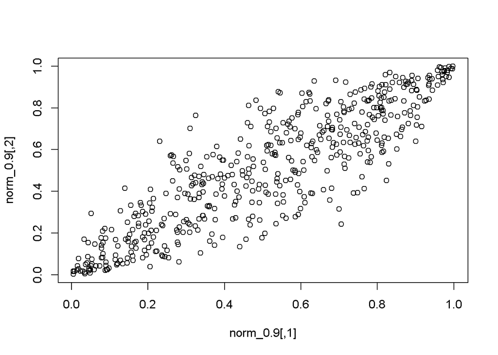

```r
# Parte 3)

plot(norm_0.9)
```

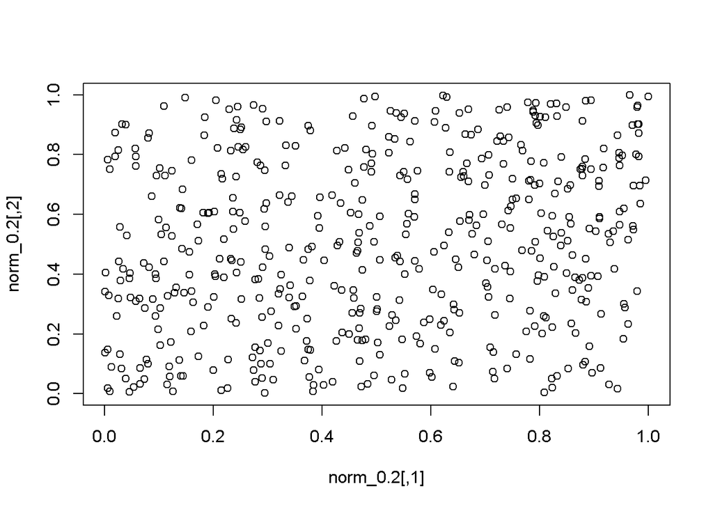

```r
plot(norm_0.2)
```

Con el de 0.9?

Exercise 4 The copula package offer two other ways to visualise a copula: the function persp() give you the ability of doing a 3d plot of the copula and contour() generate a contour plot of a copula. Use those two functions to visualise the copula from exercise 1.

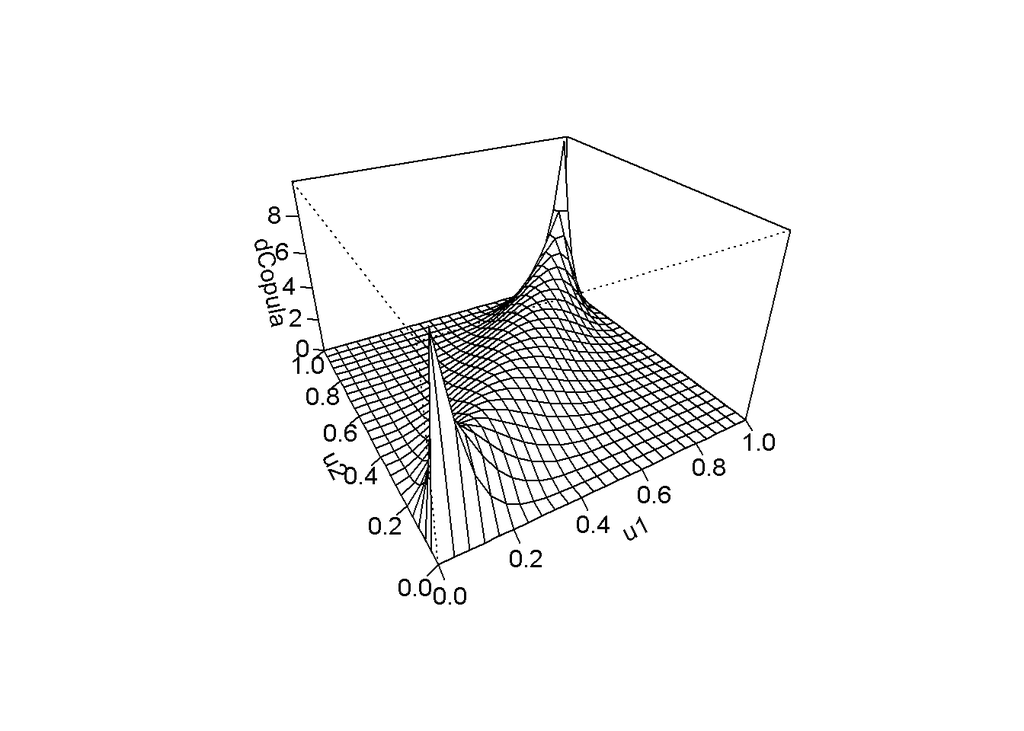

```r
# Parte 4)

persp(normal_0.9,dCopula) #3d plot of copula
```

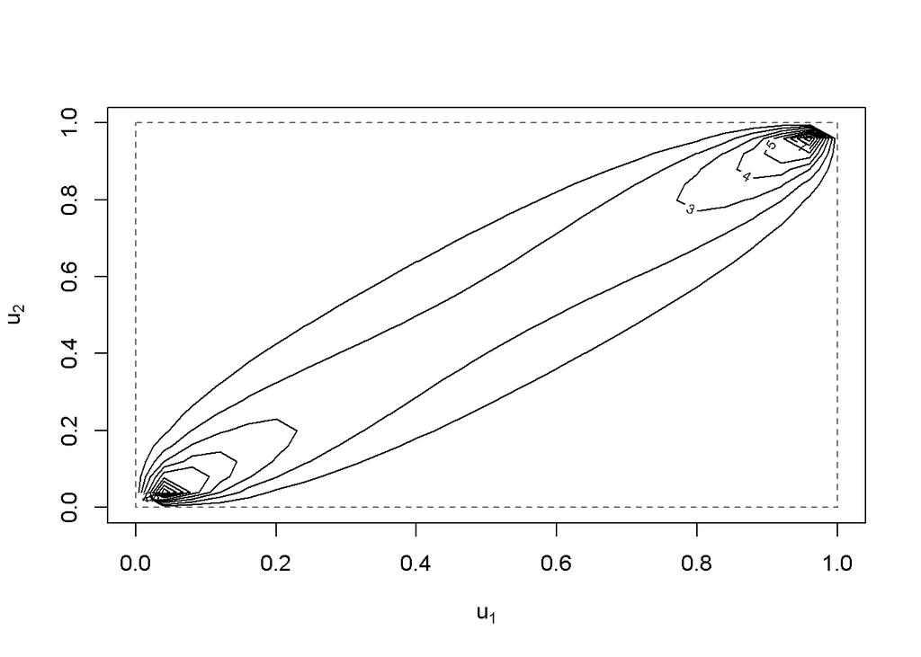

```r
contour(normal_0.9,dCopula) #contour plot of copula
```

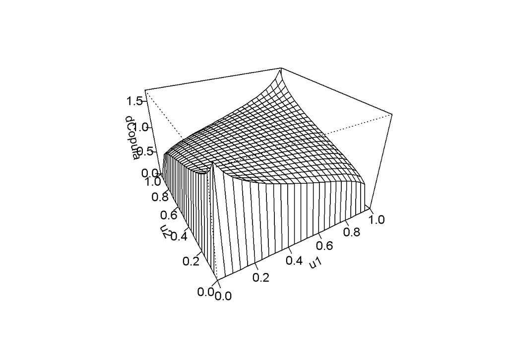

```r
persp(normal_0.2,dCopula)
```

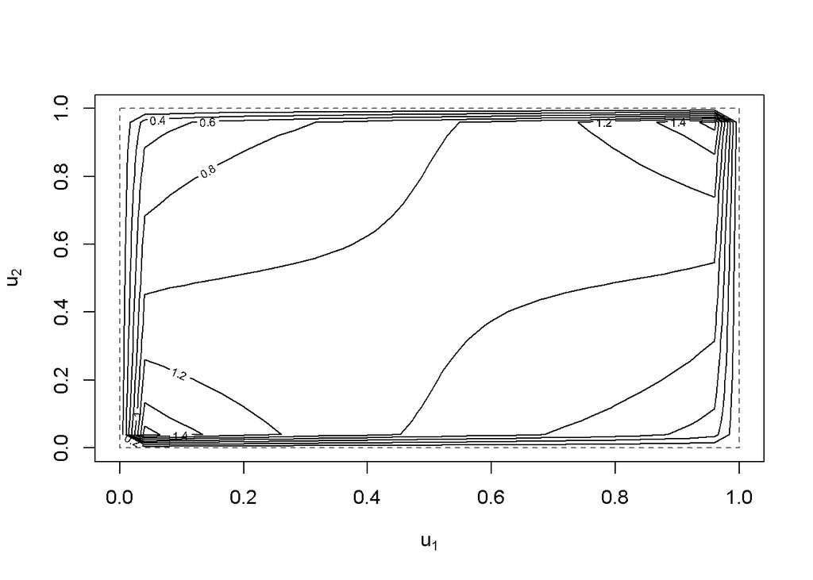

```r
contour(normal_0.2,dCopula)
```

Parece ser mejor la cúpula 2.

Exercise 5 Use the mvdc() function to create two multivariate joint distributions from the copula from exercise 1 with normal margins. Those margins should have a mean of 2 and 5 and a standard deviation of 3 and 1 respectively. Then apply the persp() and contour() to visualise the two distributions. Do the margins of the two distribution change in the two plots?

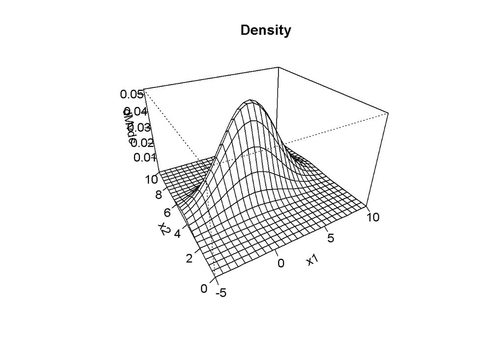

```r
# Parte 5)

norm_dist <- mvdc(copula = normal_0.2, margins = c("norm", "norm"), paramMargins = list(list(mean = 2, sd=3),list(mean = 5, sd=1)) )

persp(norm_dist, dMvdc, xlim = c(-5,10), ylim=c(0, 10), main ="Density")
```

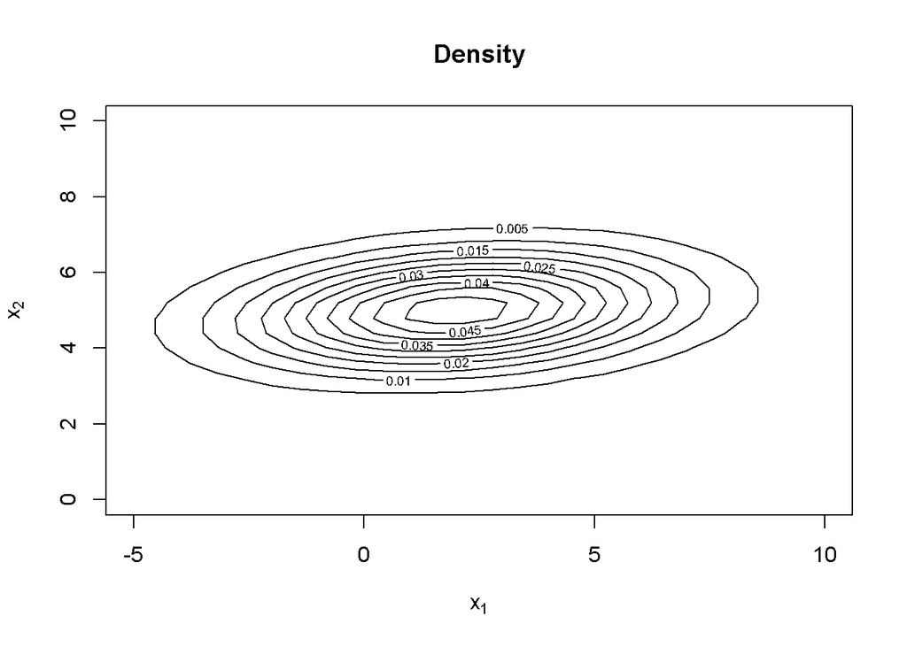

```r
contour(norm_dist,dMvdc, xlim = c(-5,10), ylim=c(0, 10), main ="Density")
```

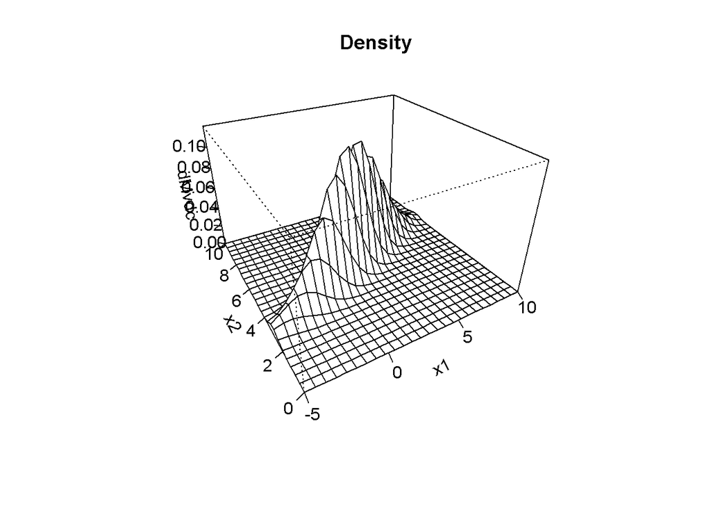

```r
norm_dist <- mvdc(copula = normal_0.9, margins = c("norm", "norm"), paramMargins = list(list(mean = 2, sd=3),list(mean = 5, sd=1)) )

persp(norm_dist, dMvdc, xlim = c(-5,10), ylim=c(0, 10), main ="Density")
```

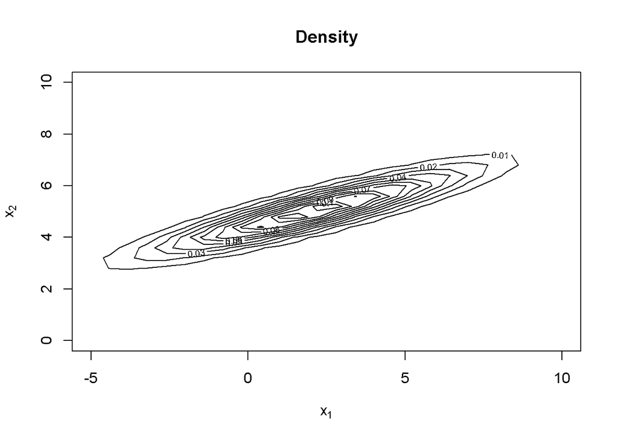

```r
contour(norm_dist,dMvdc, xlim = c(-5,10), ylim=c(0, 10), main ="Density")
```

No cambia

Exercise 6 Repeat the steps of exercise 5, but this time creates two multivariate joint distributions with different margins. The first one must be a student distribution with 9 degrees of freedom and the second one should be an exponential distribution with a rate of 0.3. How those plots different from those of exercise 5?

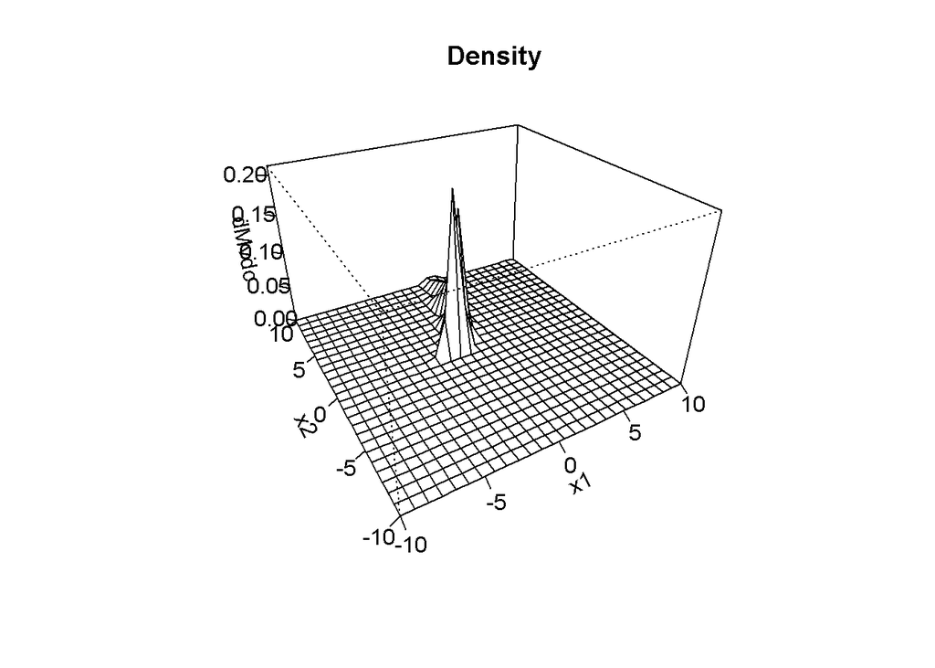

```r
# Parte 6)

t.exp.dist <- mvdc(copula = normal_0.9, margins = c("t", "exp"), paramMargins = list(list(df = 9), list(rate =0.3)))

persp(t.exp.dist, dMvdc, xlim = c(-10,10), ylim=c(-10, 10), main ="Density")
```

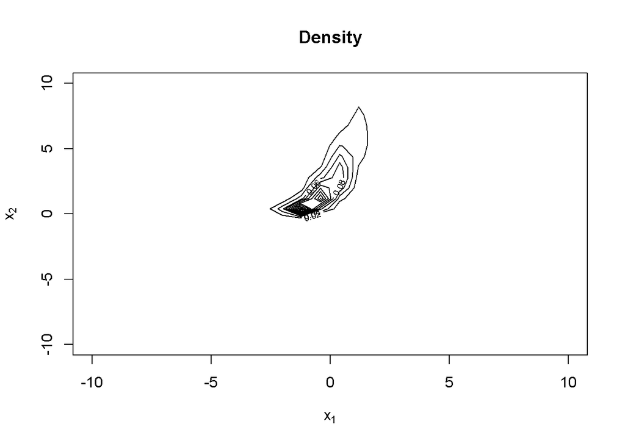

```r
contour(t.exp.dist,dMvdc, xlim = c(-10,10), ylim=c(-10, 10), main ="Density")
```

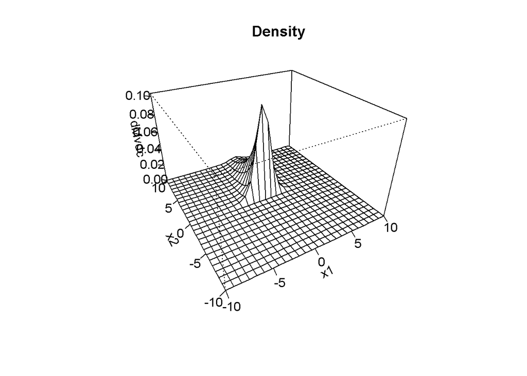

```r
t.exp.dist <- mvdc(copula = normal_0.2, margins = c("t", "exp"), paramMargins = list(list(df = 9), list(rate =0.3)))

persp(t.exp.dist, dMvdc, xlim = c(-10,10), ylim=c(-10, 10), main ="Density")
```

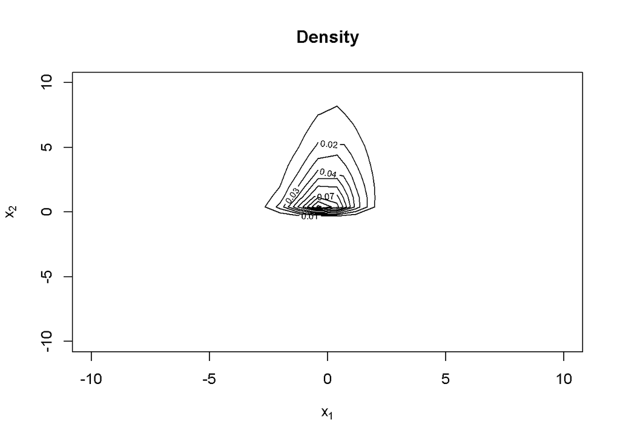

```r
contour(t.exp.dist,dMvdc, xlim = c(-10,10), ylim=c(-10, 10), main ="Density")
```

Si cambia, no? Exercise 7 Sample 500 points from the multivariate joint distribution made with a Gaussian copula of parameter 0.9 you did in the exercise 5. Then use the hist3D() and image2D() function from the plot3d package to plot the distribution of those points.

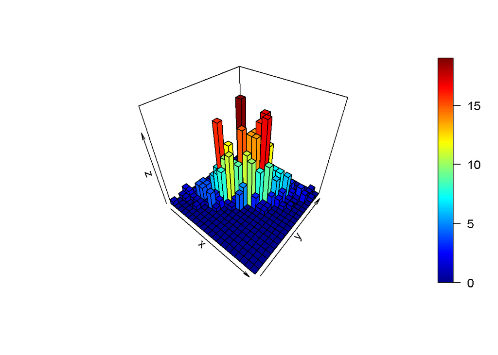

```r
# Parte 7)

sample.norm.dist <- rMvdc(500, norm_dist)
library(plot3D)

x.cut <- cut(sample.norm.dist[,1], 20)
y.cut <- cut(sample.norm.dist[,2], 20)
z <- table(x.cut, y.cut)

hist3D(x=seq(-5,10,length.out= nrow(z)), y=seq(0,10,length.out= nrow(z)),z=z, border="black")
```

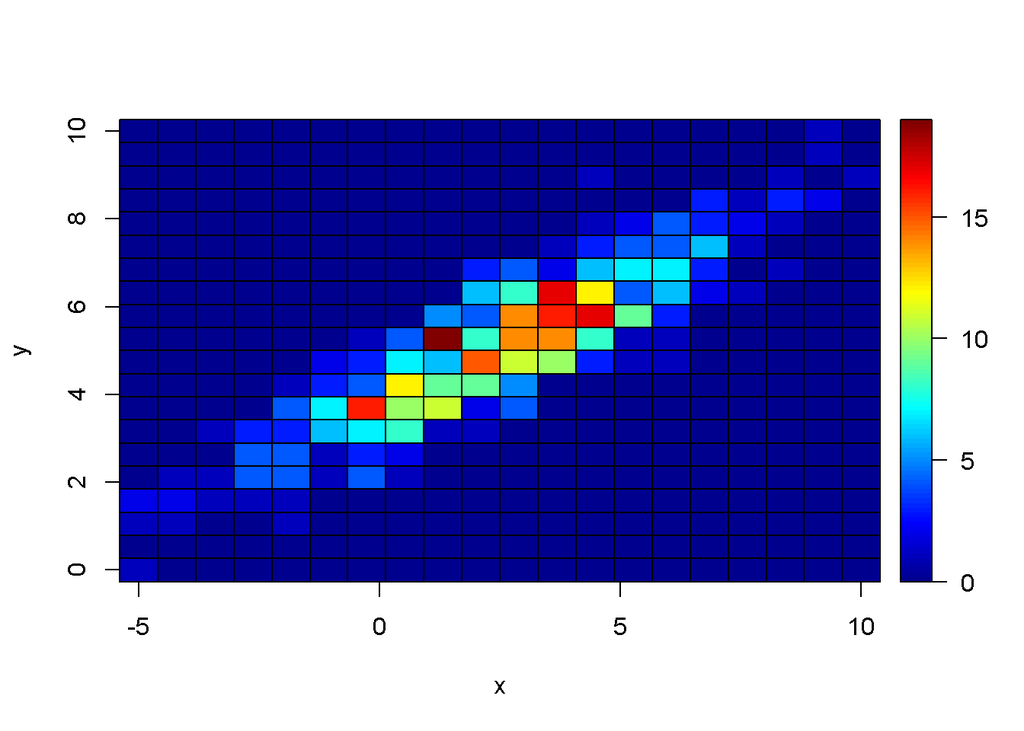

```r
image2D(x=seq(-5,10,length.out= nrow(z)),y=seq(0,10,length.out= nrow(z)),z=z, border="black")
```

Exercise 8 Create a two dimensional Clayton copula with a parameter of 15, then plot it using persp() and contour(). Sample 500 points from this copula and plot them using qplot(). Then follow the step of the exercise 5, but this time use the Clayton copula you just created. Repeat this process, this time with a two dimensional Clayton copula with parameter of 1.

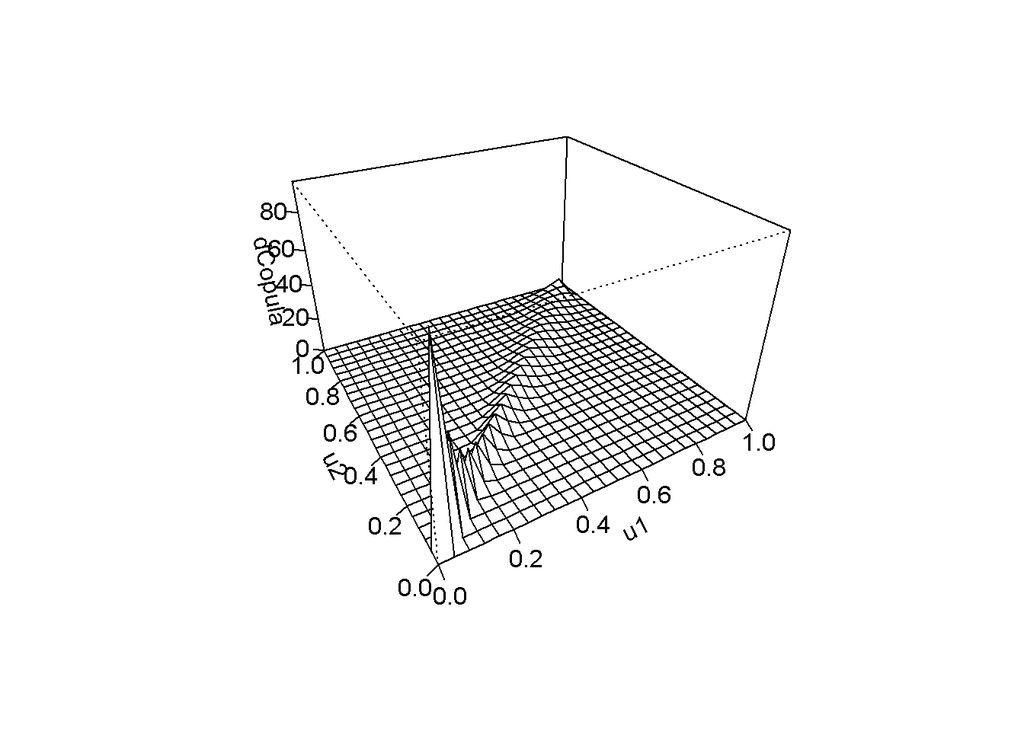

```r
# Parte 8)

clayton.15 <- claytonCopula(param = 15, dim = 2 )

persp(clayton.15, dCopula)
```

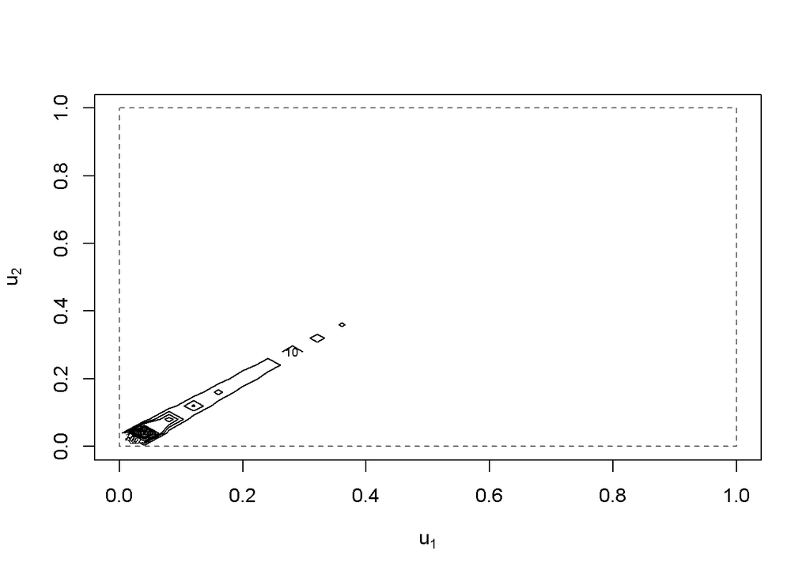

```r
contour(clayton.15, dCopula)
```

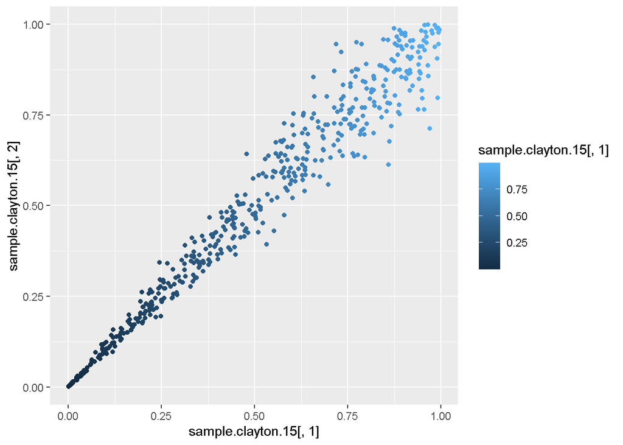

```r
sample.clayton.15 <- rCopula(500, clayton.15)
qplot(sample.clayton.15[,1], sample.clayton.15[,2], colour = sample.clayton.15[,1])
```

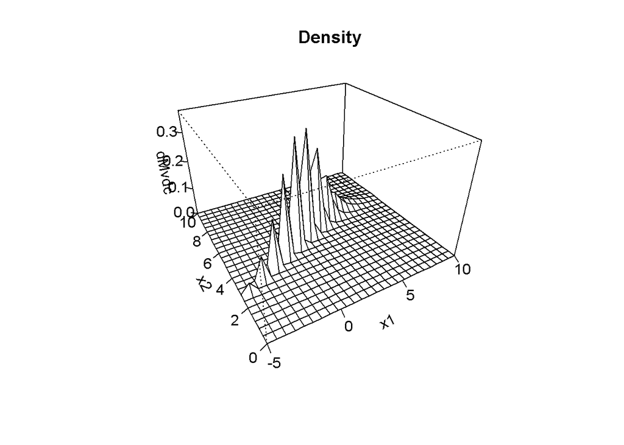

```r
clayton.15.dist <- mvdc(copula = clayton.15, margins = c("norm", "norm"), paramMargins = list(list(mean = 2, sd=3),list(mean = 5, sd=1)) )
persp(clayton.15.dist,dMvdc, xlim = c(-5,10), ylim=c(0, 10), main ="Density")
```

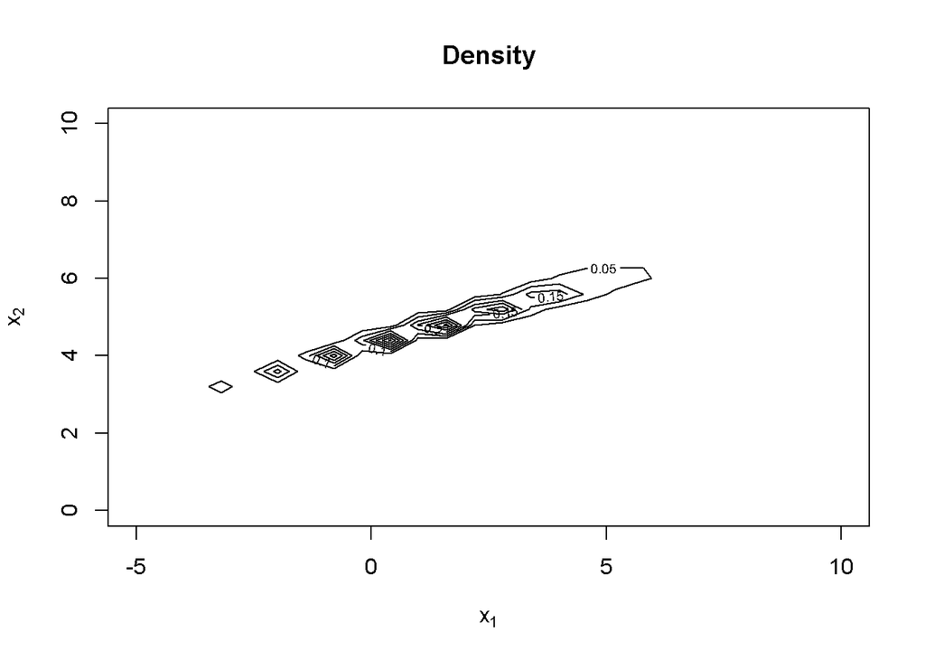

```r
contour(clayton.15.dist,dMvdc, xlim = c(-5,10), ylim=c(0, 10), main ="Density")
```

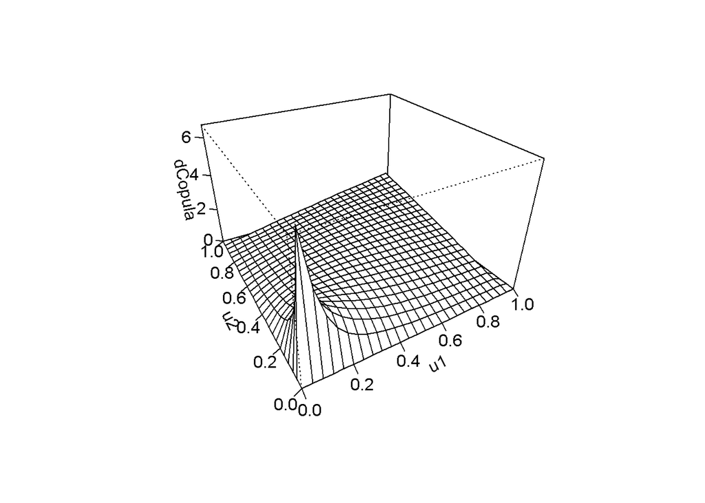

```r
#############################

clayton.1 <- claytonCopula(param = 1, dim = 2 )

persp(clayton.1, dCopula)
```

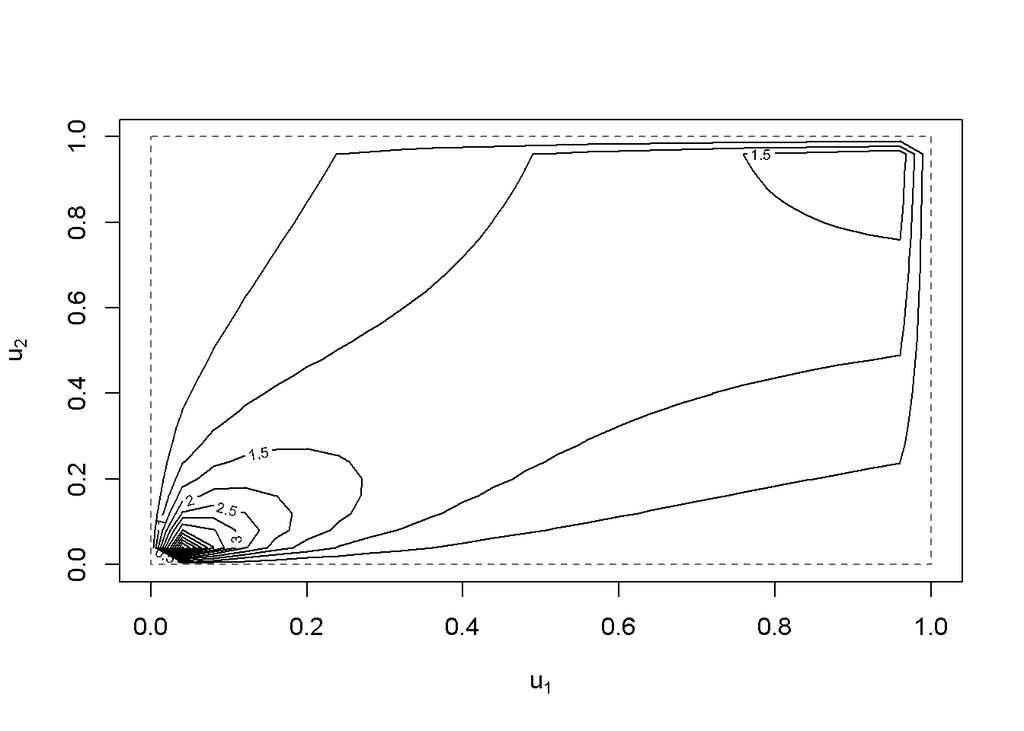

```r
contour(clayton.1, dCopula)
```

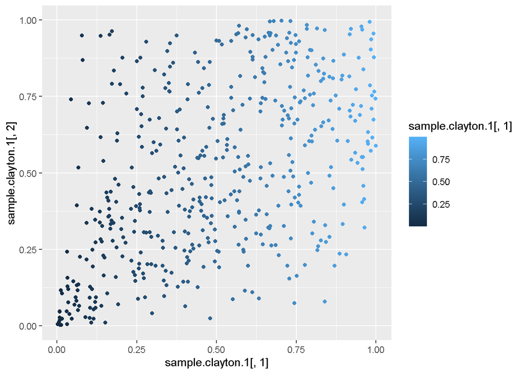

```r
sample.clayton.1 <- rCopula(500, clayton.1)
qplot(sample.clayton.1[,1], sample.clayton.1[,2], colour = sample.clayton.1[,1])
```

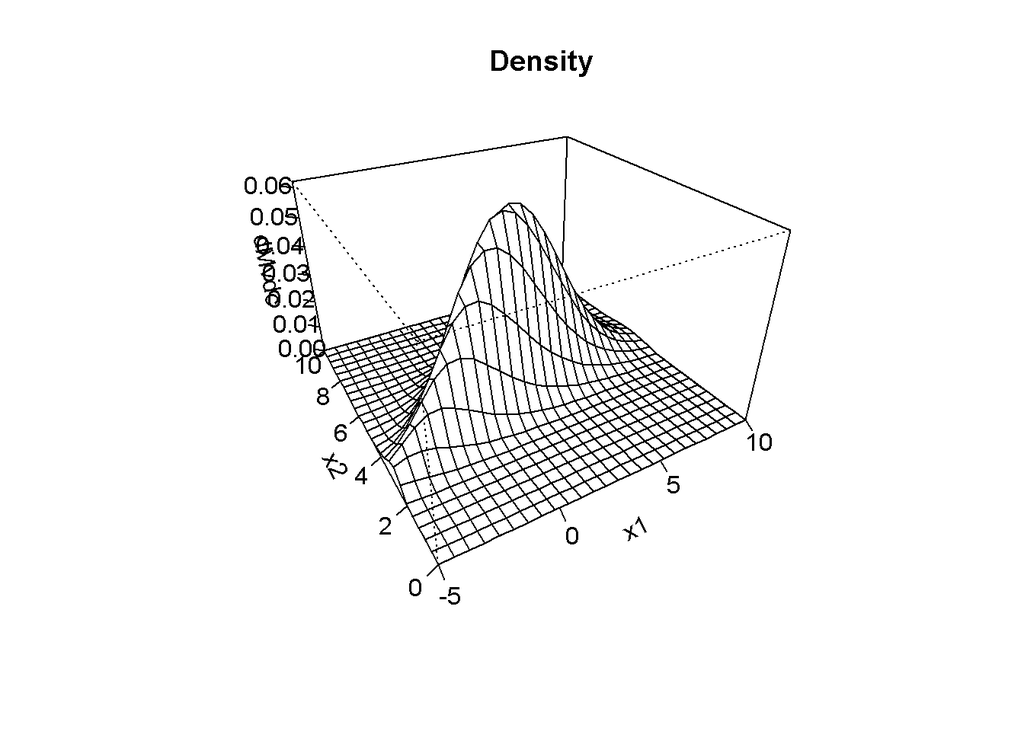

```r
clayton.1.dist <- mvdc(copula = clayton.1, margins = c("norm", "norm"), paramMargins = list(list(mean = 2, sd=3),list(mean = 5, sd=1)) )
persp(clayton.1.dist,dMvdc, xlim = c(-5,10), ylim=c(0, 10), main ="Density")
```

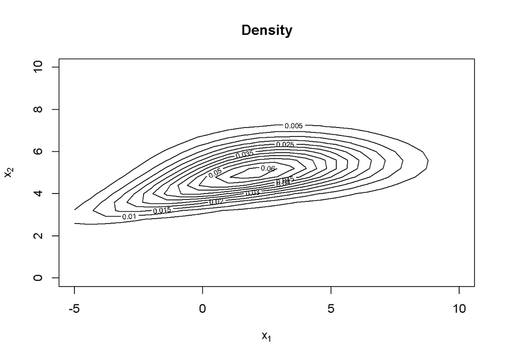

```r
contour(clayton.1.dist,dMvdc, xlim = c(-5,10), ylim=c(0, 10), main ="Density")
```

Exercise 9 Repeat the exercise 8, but use a two dimensional Frank copula of parameter 19 and another of parameter 1. Take time to notice how the parameter affect the shape of the multivariate joint distribution

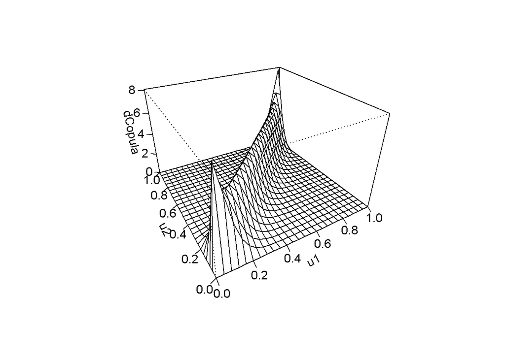

```r
# Parte 9)

frank.19 <- frankCopula(param = 19, dim = 2 )

persp(frank.19, dCopula)
```

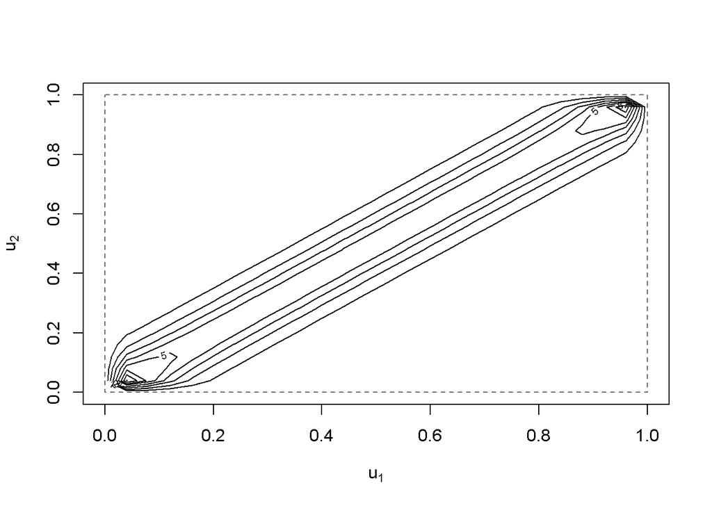

```r
contour(frank.19, dCopula)
```

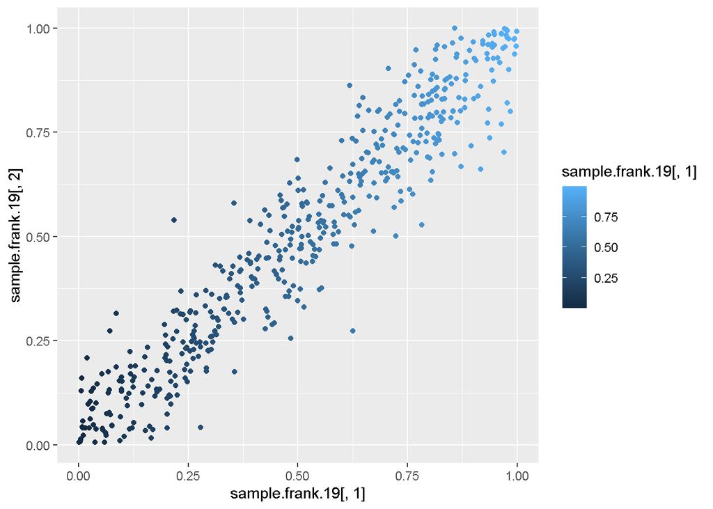

```r
sample.frank.19 <- rCopula(500, frank.19)
qplot(sample.frank.19[,1], sample.frank.19[,2], colour = sample.frank.19[,1])
```

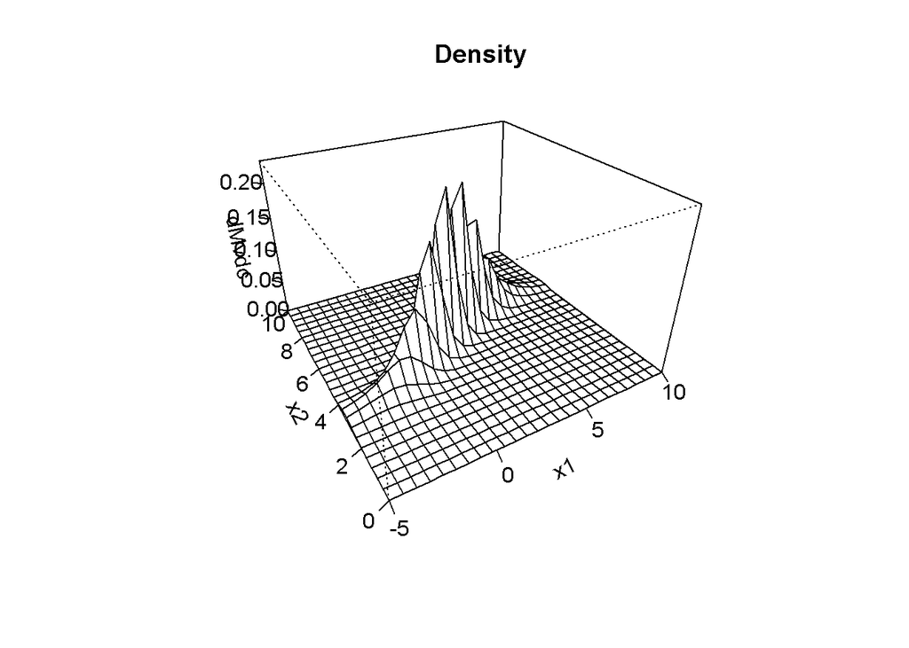

```r
frank.19.dist <- mvdc(copula = frank.19, margins = c("norm", "norm"), paramMargins = list(list(mean = 2, sd=3),list(mean = 5, sd=1)) )
persp(frank.19.dist,dMvdc, xlim = c(-5,10), ylim=c(0, 10), main ="Density")
```

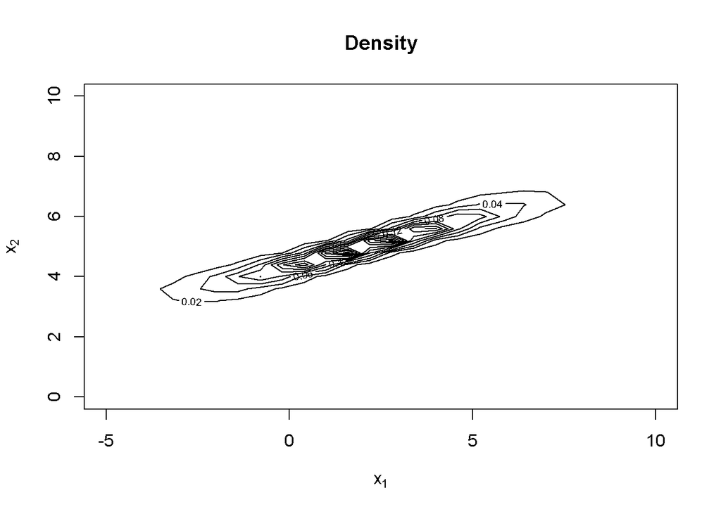

```r
contour(frank.19.dist,dMvdc, xlim = c(-5,10), ylim=c(0, 10), main ="Density")
```